# So no one told me life was gonna be this way…

Author

Ashley E. Mullan

Published

July 12, 2024

## My Questionable Netflix Habits (Spoiler Alert!)

One of my most toxic traits is my tendency to speed up my streaming to as fast as double the intended pace. That being said, I get through a lot of TV in my (limited) free time. During the pandemic, my best friend introduced me to *New Girl*, which became (and still is) a large part of my personality. I have a (potentially unhealthy) obsession with Season 2 Episode 15, which I will spoil as the episode where Nick and Jess first kissed on screen. During my time at Wake Forest, [Sarah Lotspeich](https://sarahlotspeich.com) and I realized that assessing this episode was the PERFECT setting for me to learn how interrupted time series works. We turned this project first into a poster at the 2023 WSDS Conference (see my talks page) and later an article for Significance Magazine’s [2024 early career writing competition.](https://significancemagazine.com/2024-writing-competition-finalists-announced/) I was so excited to find out that my article was highly commended by the editors, so I turned it into a blog post! Huge thanks to Sarah for her help pulling this project together.

## For Better or For Worse: The First Kiss Effect on Television Ratings

### Abstract

My day job might be (bio)statistics, but at my core, I’m a sucker for love. Picture your favorite “will they or won’t they” TV couple, you know, the one that you just KNOW is destined to be together forever. From the first episode, they’ve got this insane chemistry that just doesn’t quit. Their dynamic constantly shifts between almost-romance and friendship, and you’re just sitting there, binge watching, waiting for them to just KISS ALREADY! For me, that couple is Nick Miller and Jess Day from the show *New Girl*, and that big moment (the one we’ve all been waiting for) comes in Season 2, Episode 15. For Nick and Jess, and other couples like them, the first kiss is a pivotal moment in their character arcs, and it defines the trajectory of the plot. If you’re like me, you’re hooked. You feel the magic and are excited to see the drama coming up next, so you grab the popcorn and don’t leave the couch for at least another half season. Other people might be susceptible to the Zeigarnik effect. These folks see that kiss as the completion of the story arc. They’ll then get bored and either immediately abandon the show or slowly fizzle out when they lose interest. This dichotomy of behavior poses an interesting question to those data-minded Netflix fans. We can certainly track and quantify our own behavior to uncover our true feelings about love, or at least how we feel when we see it on the screen. Unfortunately, assessing our own behavior doesn’t yield insight about the world at large. As statisticians, our goal is to capture the feelings of the hivemind. Luckily, we have a nice way to quantify how viewers feel about television, ratings! Now, we can discover the effect of a couple’s first kiss on a show’s ratings.

### The Preface: Pardon Our Interruption

Our pursuit of quantifying this first kiss effect, or KE, falls into a space called **causal inference**. Causal questions are particularly tricky to answer, because they require us to be able to say that Event A (the couple finally kisses for the first time) directly causes Event B (a change in the show ratings) without any interference from other events happening under the hood. Luckily, statisticians have some tools that can help with these types of questions.

One such tool is the **interrupted time series (ITS)** model [(Bernal et. al)](https://pubmed.ncbi.nlm.nih.gov/27283160/). ITS models allow us to look at the trend in a sequence of observations over time and the effect of an interruption on that trend. The model takes advantage of a hypothetical situation called the **counterfactual**, an alternate timeline where the interruption never happens.

Suppose we think that viewers, on average, feel the same way I do about Nick and Jess’s on-screen kiss in *New Girl*. Then, in the real timeline, Nick and Jess’s kiss in Season 2 would interrupt the ratings trend and force the ratings to go up and stay up. However, in our alternate timeline (the counterfactual), Nick and Jess never kissed in Season 2, and the trend would stay exactly the same. To figure out the KE, we would look at the difference between our counterfactual and our reality. Specifically, we’re looking to estimate the trend before the kiss, the immediate change caused by the kiss, and the new trend after the kiss.

### The Pilot: Meet the Couples

To use the ITS model, we first need some data. Luckily, the internet is full of TV fans that have strong opinions about love. After scouring the internet for lists of these “will they or won’t they” duos, we end up with 137 couples from 108 different shows going all the way from *Cheers* and *Battlestar Galactica* in the late 1970s and early 1980s to *Never Have I Ever* and *Abbott Elementary* in the last few years. For each of these couples, we grab data from the Internet Movie Database (IMDb) and Wikipedia. Specifically, we record the season and episode of the first kiss, the couple’s internet popularity (in mentions), the number of seasons in the show, and when the show premiered. We then identify the 20 most-mentioned “will they or won’t they” couples across all the lists, and further pull episode ratings for the full run.

Before fitting the model to answer our question about the KE, it is always a good idea to look at [our data](https://figshare.com/articles/dataset/Will_They_or_Won_t_They_Couples_Data/24456844) and check for any interesting patterns. I had two specific questions in mind!

*Question 1: When did shows start using this trope?* The “will they or won’t they” trope isn’t new, with an early example being *Pride and Prejudice* by Jane Austen in 1813. However, the couples most cited on the internet all appear in the last 50 years’ worth of television, and most of them appear on shows that premiered within the last 30 years.

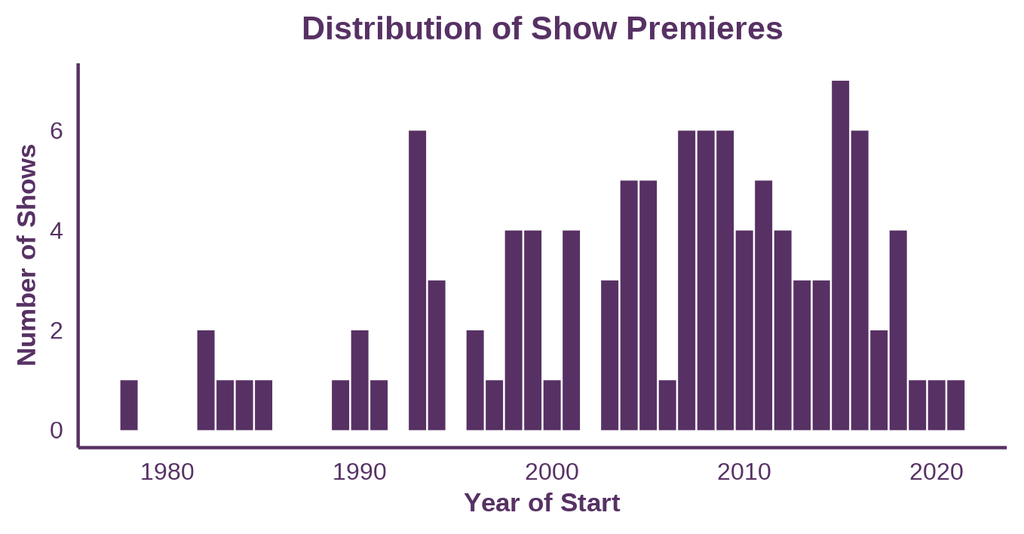

Shows from as early as the 1980s that feature the trope are still popular today. The highest bars are years where the most shows with ``will they or won’t they’’ couples premiered.

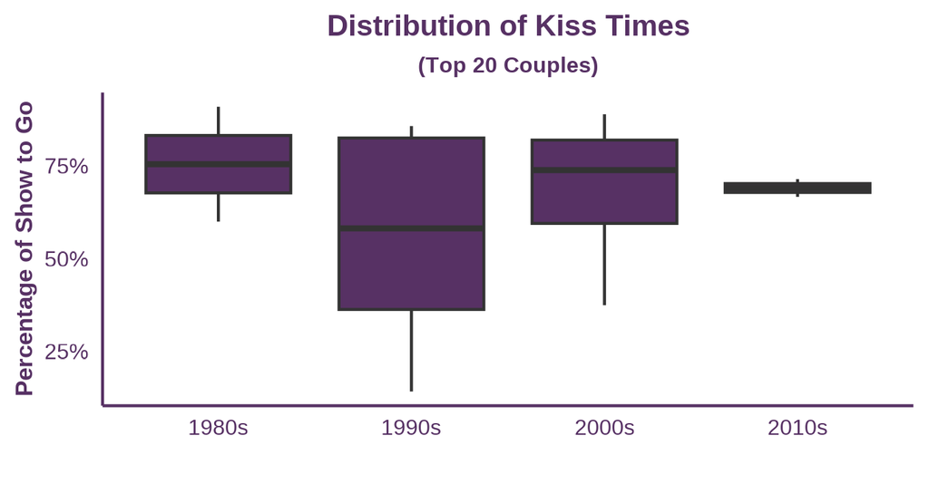

Most shows had a lot of plot still to cover after their couples’ first kisses. Does this mean the ratings were high enough to save the show? You can find the “typical” (read: median) couples by looking for the horizontal line in the middle of each decade’s box.

### The Cliffhanger: So, what happened?

Now, we fit our ITS model to estimate the KE. There are actually two ways to think about interpreting what we find. First, if we fit separate models to each couple’s data individually, we can look at the effect of one specific couple’s first kiss on their show’s ratings. Second, if we fit one model to all of the shows’ data together, we can look at the kiss effect $\sim$on average$\sim$ rather than with respect to a specific couple.

Let’s first look at a few examples of individual couples and shows, starting with Nick and Jess from *New Girl*. In the pre-kiss portion of the show (episodes represented by blue dots in the plot), we see ratings going slightly up, and the counterfactual (the dotted line) would be if that trend persisted across the entire show. Sadly, the real ratings seem to fall prey to the Zeigarnik effect. They are expected to immediately drop by 0.1 rating points after the first kiss (episodes represented by pink dots in the plot) and decrease by 0.003 rating points episode-on-episode for the remainder of the show’s run, never to recover (the right piece of the solid line). However, like good statisticians, we quantify our uncertainty with confidence intervals before totally giving up on Nick and Jess.

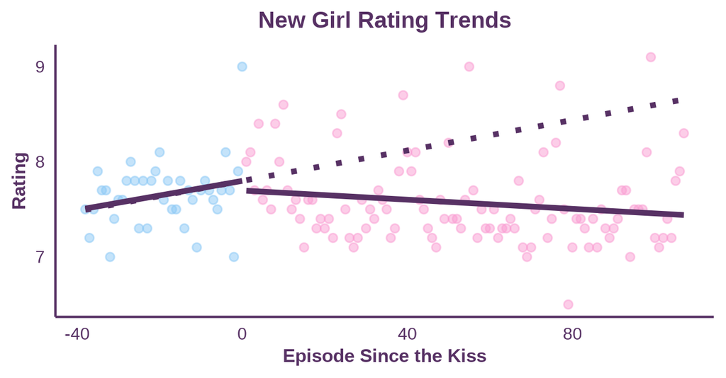

Did *New Girl* go downhill after Nick and Jess’s first kiss? Each point represents an episode of the show, where higher points received higher ratings. The solid lines represent the actual trend, whereas the dashed line represents the counterfactual trend.

The confidence intervals give a plausible range of where our kiss effect might actually land, after accounting for any quirks in the data. In short, a confidence interval adds some wiggle room around the model’s guess at the trend in ratings. Different levels of confidence are possible, depending on how willing we are to accept the possibility of being wrong about the true size of the first kiss effect, but 95% is commonly used. In our case, the 95% confidence interval for the immediate interruption in *New Girl* episode ratings following Nick and Jess’s first kiss is between a 0.34 decrease and a 0.14 increase in ratings. Thus, despite the slight visible jump when going from before to after the kiss, there is not enough evidence in our data to support that one truly exists. Both increases and decreases in ratings fall into our uncertainty range. Also, despite the plot showing a switch from an episode-on-episode increase before the kiss to a decrease after, the data similarly cannot exclude the possibility of no change at all.

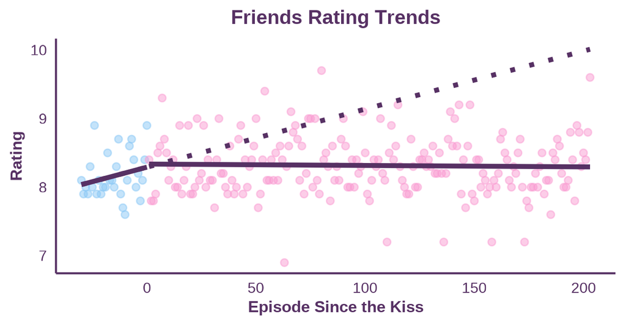

Ross and Rachel’s story isn’t over after they kiss. Each point represents an episode of the show, where higher points received higher ratings. The solid lines represent the actual trend, whereas the dashed line represents the counterfactual trend.

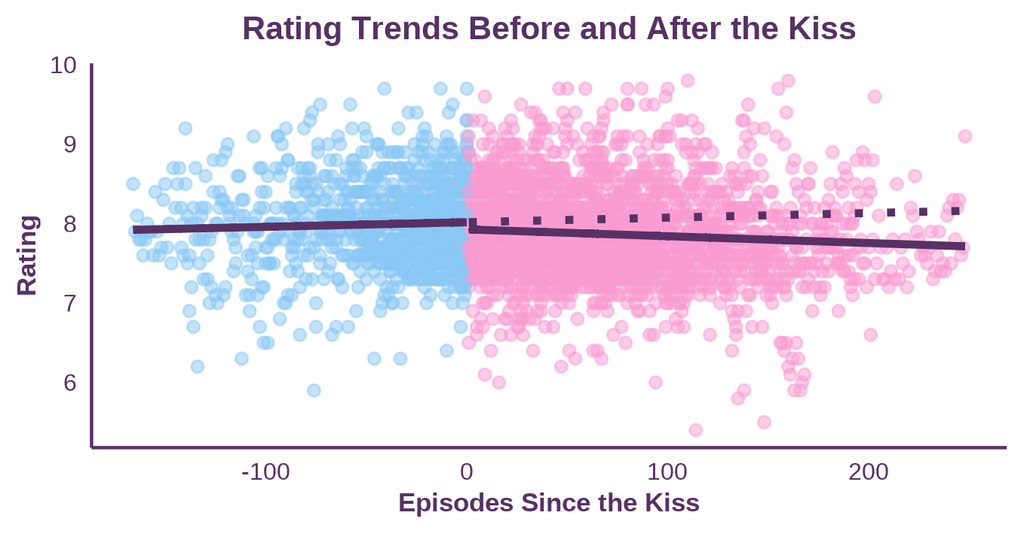

We can get a better sense of the average KE by zooming out to look at all twenty of our top couples together. Look at the difference in direction on that counterfactual!

### The finale: Take note, spin-offs

Unfortunately, it seems like my TV habits differ from the rest of the world. While I can’t wait to see how a love story plays out, the Zeigarnik effect kicks in quickly for other viewers. Show ratings start to decline after the “will they or won’t they” couple finally has their first kiss, and in many cases they continue to decline for the rest of the show, never to attain pre-kiss levels. If Hollywood wants to keep their ratings high and viewers interested, they may want to consider either standing strong and delaying these moments to the end of the show or introducing another dramatic storyline to the plot. So much for love, right?

## Time for a plot twist 📖

You can’t have TV without popcorn, right? A friend of mine recently visited me and brought the coolest tin of gourmet popcorn with him. Of course, that got me thinking about popcorn! Here are some [fun facts about popcorn.](https://www.bestdarnkettlecorn.com/20-fun-facts-you-didnt-know-about-popcorn/) Did you know that January 19th is National Popcorn Day? I didn’t!

Thanks for reading, and enjoy your popcorn! 🍿🍿🍿